## Introduction

Every year, there are more then 800,000 people who take their own life, and many more suicides are attempted. In other words, there is one suicide in the world every 40 seconds. Suicide happens globally across ages and genders with different rates. In the United States, it is the second leading cause of death for people aged 15-29, and the tenth leading cause of death for all ages. Suicide is a serious problem worldwide, but it is the most preventable when comparing to other leading causes of death. The first-ever Mental Health Action Plan of the World Health Organization was conducted in May 2013. The goal is to reduce the suicide rate by 10% by 2020 in nations.

Here, I analyze suicide rates in the United States and across the world. The goal is to provide an insight into this topic and hope this data can be used to prevent suicides in the future.

[figure not shown]

## The Geography of Suicide

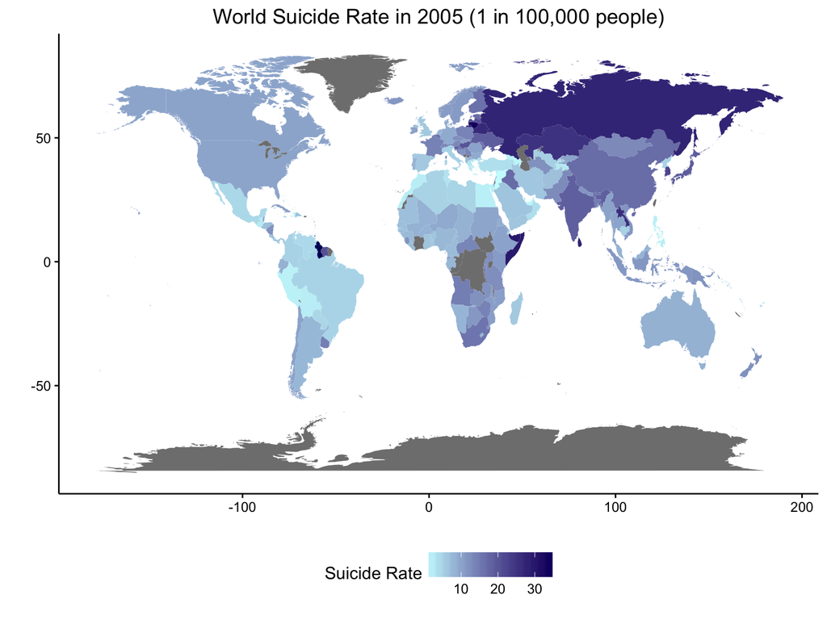

#### Top 10 countries with the highest suicide rate in 2005.

| Country | Suicide Rate |
| --- | --- |
| Guyana | 35.75287 |
| Lithuania | 33.34186 |
| Somalia | 29.86416 |
| Sri Lanka | 28.10405 |
| Russia | 27.87416 |
| Belarus | 26.87469 |
| Laos | 26.21920 |
| Kazakhstan | 25.40460 |
| South Korea | 22.40456 |
| Maldives | 22.35348 |

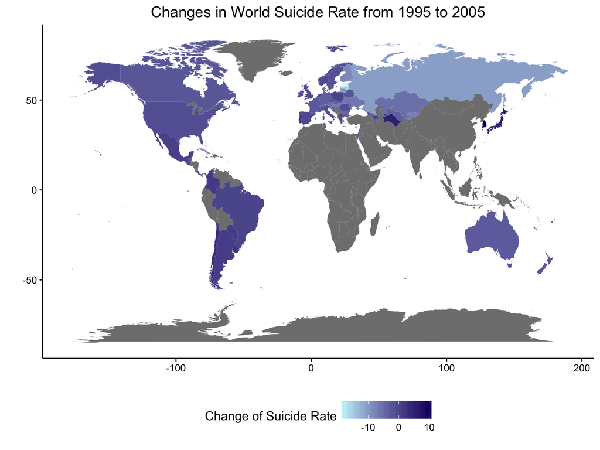

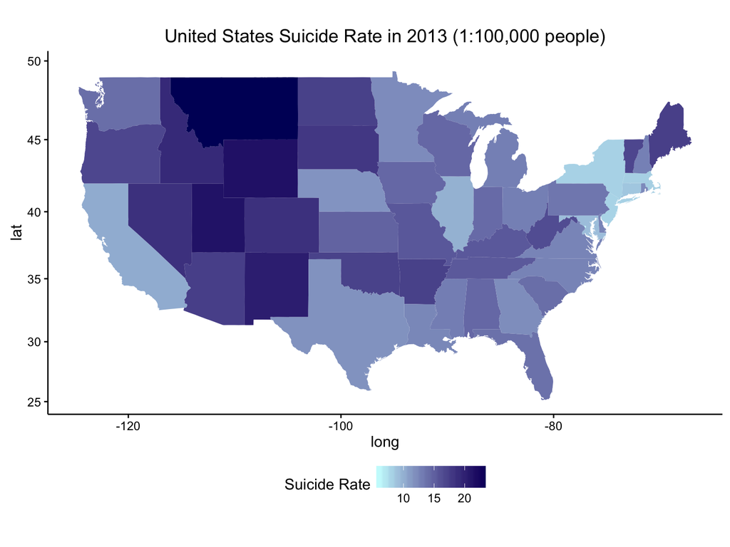

## Who is at risk?

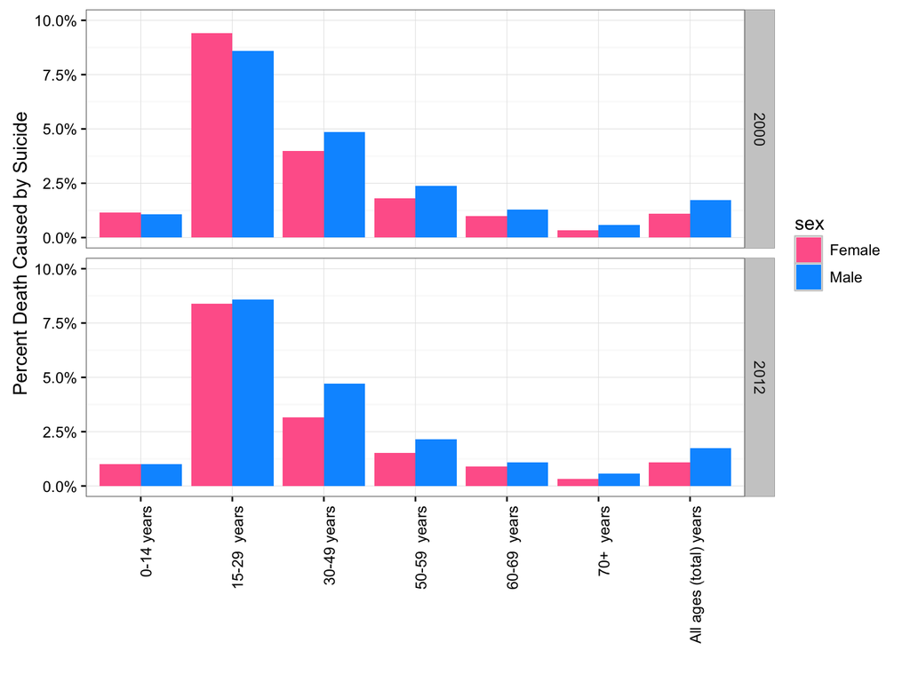

## What factors influence suicide behavior?

People choose to end their lives for complex reasons. It is difficult to pin down the cause of suicide. Commonly cited reasons include: * Life history: traumatic experience during childhood, and sexual/physical abuse. * Life style: alcohol or drug abuse. * Life event: loss of loved ones or loss of income. * Mental heath: depression or schizophrenia Here I explored a few factors that I think would impact suicide rate.

#### Unemployment

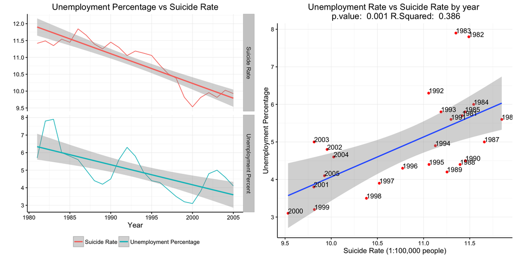

The figures above demonstrate the relationship between unemployment and suicide rates over time. Another way to analyze this relationship is to examine it state by state. The figure below shows the correlation between unemployment rate and suicide rates by states in 2013. Interestingly, the result suggests the opposite from the above figure. We see a negative linear relationship. One of the explanations is that 2013 could be the outlier of the trend established from the above figure. Other possibility is that the trend changes after 2005. Since the figure below uses data from 2013, it wouldn’t fit in the trend established from 1995 to 2005.

From our analysis, we can conclude that there is a positive relationship between unemployment rate and suicide rate between 1995 and 2005. The trends of the two variables after 2005 remain unclear from this analysis.

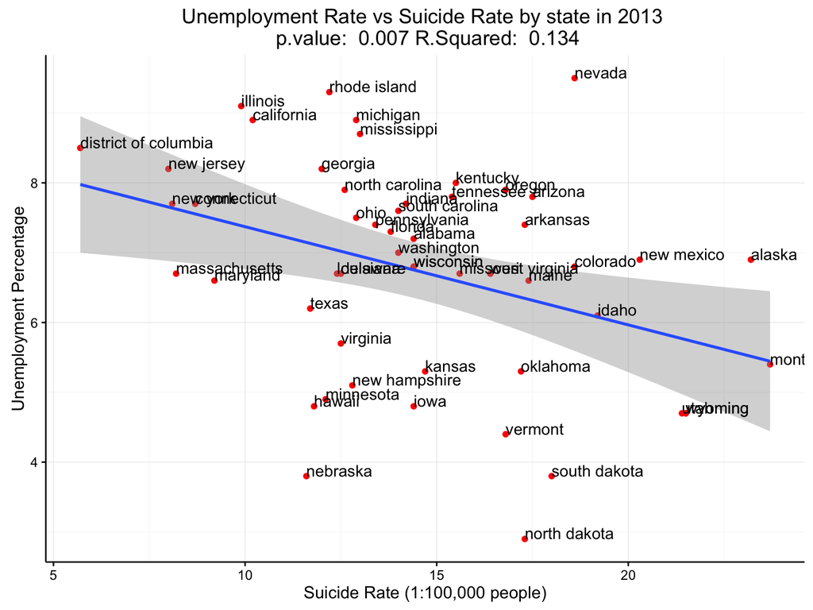

#### School Enrollment

The theory is that students who drop out of school are likely to be experiencing negative life events, which could make them more vulnerable to commit suicide. This analysis explores the relationship between school enrollment rate and suicide rate. School enrollment rate showed here is the percentage of total population aged 3 years old and above who are enrolled in school. From the left figure we see a negative trend between the two variables. The suicide rate decreases as school enrollment rate increase between year 1999 and 2013. We further analyze the correlation between the two variables (right figure) and indeed there is a strong negative linear relationship.

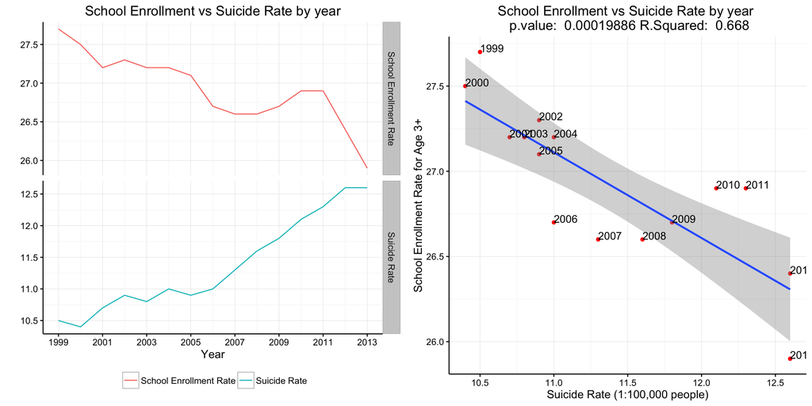

#### Alcohol Consumption

Alcohol consumption and suicide rate seem to have a close relationship. Even though alcohol consumption might not be causal, it tends to give user the mindset to commit suicide. This analysis examines the relationship between alcohol consumption and suicide rate across states. Alcohol consumption used in this dataset is any alcohol use, meaning one or more drinks during the last 30 days of the survey. The result surprisingly shows the opposite as our assumption. The graph demonstrates a negative linear relationship between alcohol consumption and suicide rate. However, the data points are sparse and the variance explained is also very small. The correlation is weak therefore the relationship between the two remains inconclusive.

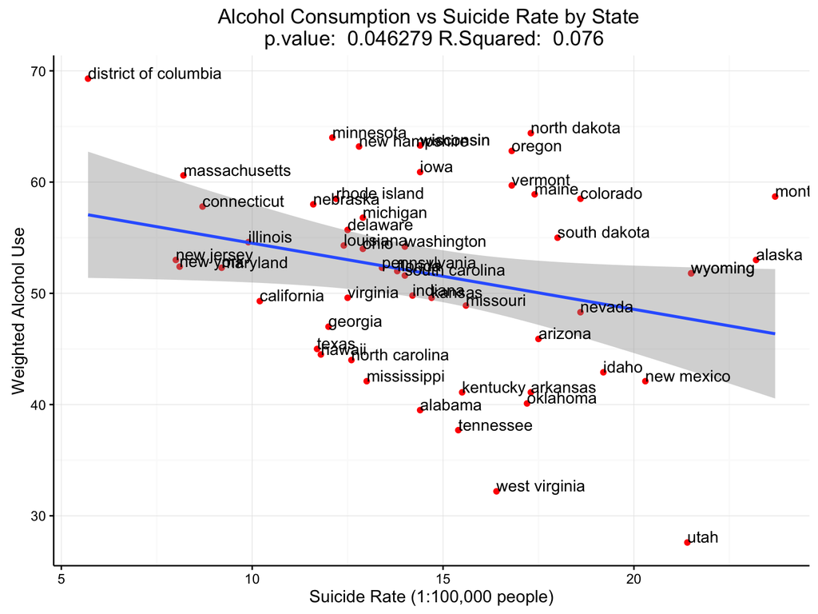

#### Coorelation does not imply causation

From the analysis above, we see strong correlations between suicide rate and some factors, which may contribute to suicide rate. However, one thing that is very important to keep in mind is that correlation doesn’t imply causation. For example, we concluded that people who are unemployed are at higher risk for committing suicide, but we cannot say unemployment is what caused suicide. As data scientists, we should be careful not to use correlation as the basis of a hypothesis for a causal relationship. As an example, we examine the relationship between cheese consumption and suicide rate. The results suggest that increased American cheese consumption will lead to higher suicide rate, and increased cottage cheese consumption will lower suicide rate. We indeed observe the relationship between cheese consumption and suicide rate; however, we are missing the factor or factors linking the two variables and cannot say American cheese consumption causes suicide. No matter how strong the correlation is, it doesn’t imply causation.

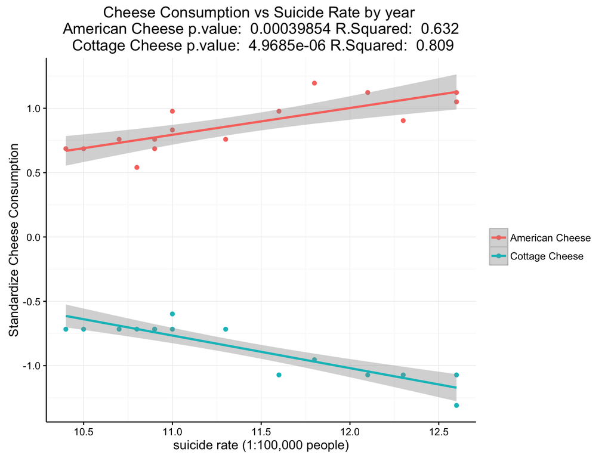

## Conclusion

I hope that the above finding can be useful for developing suicide prevention strategy.

Reference

1. Mortality due to self-inflicted injury, per 100 000 standard population, age adjusted. WHO Global Burden of Disease.
2. Mortality and global health estimate cause of heath. WHO Global Health Observatory data repository.
3. Unemployment Rates for States Annual Average Rankings Year: 2013. Bureau of labor statistics, United States Department of Labor.
4. CPS Historical Time Series Tables on School Enrollment. United States Census Bureau.
5. State-Specific Alcohol Consumption Rates for 2013. Center of Disease Control and Prevention.
6. Dairy products: Per capita consumption, United States (Annual). United States Agriculture Economic Research Service.